# Plot phylogenetic tree and identify outliers

Madeleine J.S. Gundersen

2023-06-27

This R-notebook document shows how a user can investigate their phylogenetic tree and identify outliers. The outline is as follows

1. Input your phyloseq object and plot is with cirlular layout using ggtree package.
2. If outliers are present identify them
3. Give the script your fasta file and it will make a new fasta file containing only the “suspicious” sequences
4. Input this new fasta file to BLAST and download the XML report for all samples.
5. Input the XML report back into R
6. In this script the top 5 BLAST matches per OTU/ASV is kept. But you can modify this to your preference.
7. Match the accession number for each match to taxonomic information from NCBI. If all 5 matches are “Bacteria” we keep the ASV. If they are not bacteria, the program will display the BLAST information to you and you have to decide if the OTU/ASV should be removed.
8. You are given a vector containing the biased sequences and can make a new phyloseq object without these biased ASVs/OTUs.
9. Plot the tree again and see if you need to repeat.

```r
# load packages
library(phyloseq)
library(ggtree)
library(ggplot2)
library(tibble)
library(dplyr)
library(xml2)
library(rentrez)
library(kableExtra)
```

In this document an experiment containing outlier sequences was used to exemplify the code and method.

# Inspect the phylogenetic tree and identify outliers

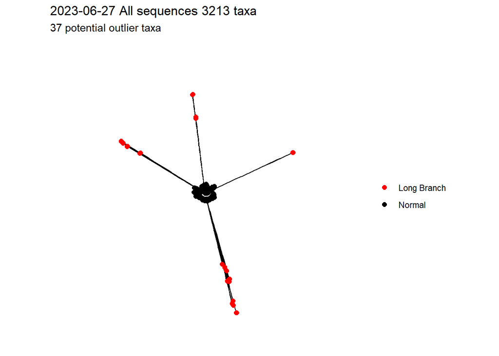

```r
# Name title to be displayed in plot
dataset_title = "All sequences"

# Display the tree in a circular layout using the ggtree package
ggtree_obj = ggtree::ggtree(phyloseq_all_sequences) +
  ggtree::layout_circular()
# Identify taxa with long branches
branch_cutoff_outlier = 3#adjust if needed
long_branch_taxa = ggtree_obj$data$label[ggtree_obj$data$branch > branch_cutoff_outlier]

# Find number and names of outlier taxa
long_branch_taxa_df = data.frame(outliers = long_branch_taxa) %>% unique() %>% na.omit()

# Highlight taxa with long branch lengths in red
# Display the updated tree
ggtree_obj +
  ggtree::geom_tippoint(aes(color = ifelse(label %in% long_branch_taxa, "Long Branch", "Normal")),
                        size = 2) +
  ggplot2::scale_color_manual(values = c("Normal" = "black", "Long Branch" = "red")) +
  ggplot2::theme(legend.position = "right",
                 legend.title = element_blank()) +
  ggplot2::ggtitle(label = paste0(Sys.Date(), " ", dataset_title, " ", ntaxa(phyloseq_all_sequences), " taxa"),
                   subtitle = paste0(nrow(long_branch_taxa_df), " potential outlier taxa"))
```

```r
# Save the plot if desired
plotname = "Dataset1_Phylogenetic_tree_all_sequences_with_outliers"
#ggplot2::ggsave(filename = paste0(filepath_results, plotname, ".png"), width = 10, height = 10)
```

## Export outlier sequences in fasta format

```r
seq_data <- Biostrings::readDNAStringSet(fasta_file_experiment)
```

```r
# Filter sequencing data to only contain outliers
outlier_seq_data <- seq_data[names(seq_data) %in% long_branch_taxa_df$outliers, ]
# 37 taxa
#export outlier sequences in fasta format for input to BLAST
fasta_file_name = "Dataset1_Outlier_sequences"
Biostrings::writeXStringSet(x = outlier_seq_data,
                            filepath = paste0(filepath_results,
                                              fasta_file_name, "_",
                                              length(outlier_seq_data), "sequences.fasta"))
```

```r
# Create data frame with information for outlier taxa. Can come if handy if you want to check up specific taxa
taxa_df <- data.frame(taxaID = rownames(tax_table(phyloseq_all_sequences)),
                      tax_table(phyloseq_all_sequences)) %>%
  dplyr::filter(taxaID %in% long_branch_taxa_df$outliers)

sequence_df =
data.frame(taxaID = names(outlier_seq_data),
  Sequence = as.character(outlier_seq_data))

outlier_info_df = left_join(sequence_df,taxa_df, by = "taxaID")

#save as a csv
write.csv(x = outlier_info_df, file = paste0(filepath_results, "Dataset1_outlier_phylogenetic_tree_ID_sequence.csv"))
```

# Nucleotide BLAST the outlier sequences

Go to https://blast.ncbi.nlm.nih.gov/Blast.cgi and choose “Nucleotide BLAST”.

Upload the fasta file continaing the potential outlier sequences and BLAST against Nucleotide collection (nr/nt). Try first using standard algorithm parameters.

# Analyse BLAST results

## Load XML files and format information to data frame structure

```r
# Load the XML file (one XML file per BLAST)
# set the directory where the XML files are located
xml_dir <- paste0(filepath)
# get the filenames of the XML files
xml_files <- list.files(xml_dir, pattern = "^.*\\.xml$")
# read the XML files into a list
xml_files = paste0(filepath, xml_files)
xml_list <- lapply(xml_files, xml2::read_xml)
```

You can inspect the XML file by clinking the file in the “Files” window to get a grasp of the structure. Here we are saving the description, accession number , and E-value

```r
# Initialize empty data frame to store results.
results_df = data.frame(matrix(ncol = 4, nrow = 0))
colnames(results_df) = c("Query", "Accession", "Match", "E_Value")

for (list_position in 1:length(xml_list)) {
  # if you have more XML files this script will loop over them
  xmlfile = xml_list[[list_position]]

  # Get all query nodes (one node per taxa)
  query_nodes <-
    xml2::xml_find_all(xmlfile, "//BlastOutput_iterations/Iteration")

  # Loop through query nodes and extract information
  for (i in 1:length(query_nodes)) {
    # Get query name
    query_name = xml2::xml_find_first(query_nodes[i],
                     ".//Iteration_query-def") %>%
      xml2::xml_text()

    # Get top 5 matches
    hit_nodes <- xml_find_all(query_nodes[i], ".//Hit") %>%
      head(5) #choose desired matches to keep

    # Extract match information
    for (j in 1:length(hit_nodes)) {
      match_name = xml2::xml_find_first(hit_nodes[j], ".//Hit_def") %>% xml2::xml_text()
      accession_id = xml2::xml_find_first(hit_nodes[j], ".//Hit_accession") %>% xml2::xml_text()
      evalue = xml2::xml_find_first(hit_nodes[j], ".//Hsp_evalue") %>% xml2::xml_text()
      if (length(accession_id) == 0) {
        accession_id = "no BLAST matches_check up"
        match_name = "no BLAST matches_check up"
        evalue = "no BLAST matches_check up"}
    #Save information in result_df
      results_df = base::rbind(results_df,
                               data.frame(Query = query_name,
                                          Accession = accession_id,
                                          Match = match_name,
                                          E_Value = evalue  ))}}}
```

| Query | Accession | Match | E_Value |
| --- | --- | --- | --- |
| Zotu348 | LR584419 | Salmo trutta genome assembly, chromosome: 10 | 0 |
| Zotu348 | LR778283 | Coregonus sp. ‘balchen’ genome assembly, chromosome: 31 | 8.31709e-160 |
| Zotu348 | LR778253 | Coregonus sp. ‘balchen’ genome assembly, chromosome: 1 | 3.2564e-99 |
| Zotu348 | LR584445 | Salmo trutta genome assembly, chromosome: 2 | 7.6734e-36 |
| Zotu530 | LR584420 | Salmo trutta genome assembly, chromosome: 4 | 0 |
| Zotu530 | LR584416 | Salmo trutta genome assembly, chromosome: 3 | 1.14685e-83 |
| Zotu530 | LR584428 | Salmo trutta genome assembly, chromosome: 13 | 6.90225e-81 |
| Zotu530 | LR584443 | Salmo trutta genome assembly, chromosome: 40 | 2.48249e-80 |
| Zotu530 | LR584422 | Salmo trutta genome assembly, chromosome: 28 | 8.92862e-80 |
| Zotu592 | LR778267 | Coregonus sp. ‘balchen’ genome assembly, chromosome: 15 | 2.03735e-140 |
| Zotu592 | LR584421 | Salmo trutta genome assembly, chromosome: 23 | 2.12569e-110 |
| Zotu592 | LR778279 | Coregonus sp. ‘balchen’ genome assembly, chromosome: 27 | 8.32272e-50 |
| Zotu592 | LR584441 | Salmo trutta genome assembly, chromosome: 12 | 1.08426e-43 |
| Zotu614 | LR584406 | Salmo trutta genome assembly, chromosome: 6 | 1.8012e-175 |
| Zotu614 | LR778274 | Coregonus sp. ‘balchen’ genome assembly, chromosome: 22 | 6.61724e-160 |

# Collect taxonomic information from NCBI

```r
# create an empty dataframe to store taxonomy information
taxonomy_df <- data.frame(Organism = character(),
                          taxonomy = character(),
                          Accession = character(),
                          stringsAsFactors = FALSE)

# save the accession numbers in a dataframe and remove duplicate numbers
Accession_IDs = results_df %>% select(Accession) %>% unique()

# match the accession numbers with taxonomic information
for (i in 1:nrow(Accession_IDs)) {
  # skip if Accession is missing
  if (Accession_IDs$Accession[i] == "no BLAST matches_check up") {
    taxonomy_df <- rbind(taxonomy_df, data.frame(Organism = "no BLAST matches_check up",
                                                 taxonomy = "no BLAST matches_check up",
                                                 Accession = "no BLAST matches_check up",
                                                 stringsAsFactors = FALSE))
    next
  }
  print(i)
  # use efetch to retrieve the record from GenBank
  gb = rentrez::entrez_fetch(db = "nuccore", id = Accession_IDs$Accession[i], rettype = "XML")
  # convert the XML object to a list
  xml_list = XML::xmlToList(gb)
  # extract the required information
  organism = xml_list$GBSeq$GBSeq_organism
  taxonomy = xml_list$GBSeq$GBSeq_taxonomy
  accession = xml_list$GBSeq$`GBSeq_primary-accession`
  # create a data frame
  taxonomy_df = rbind(taxonomy_df, data.frame(Organism = organism,
                                               taxonomy = taxonomy,
                                               Accession = accession,
                                               stringsAsFactors = FALSE))}

# merge taxonomy information with results dataframe
outliers_with_accession = left_join(results_df, taxonomy_df, by = "Accession")
saveRDS(object = outliers_with_accession, file = paste0(filepath_results, "outliers_BLASTed_withaccession.RDS"))
```

```r
outliers_with_accession = readRDS(paste0(filepath,"2023-06-26_outliers_BLASTed_withaccession.RDS"))
# Check that all outliers have been analyed
# The numer of queries should be the same as possible outliers
outliers_with_accession %>% select(Query) %>% unique() %>% nrow()
```

```
## [1] 37
```

# Quality control of outlier taxa

```r
# Load quality_control script
source(file = "C:/Users/madel/OneDrive - NTNU/Doktorgrad/Project 9 QPEN simulations/quality_control_sequences.R")

# COPY the command below into the Console window and make a decition for each taxa
quality_control_decition = quality_control(df = outliers_with_accession)
outliers_with_accession_decition = dplyr::left_join(outliers_with_accession, quality_control_decition, by = "Query")
saveRDS(outliers_with_accession_decition, file = paste0(filepath_results, "Dataset1_Quality_control_decition.RDS"))
```

After running the script we now have a decition for each outlier taxa

```r
outliers_with_accession_decition %>%
  kbl() %>%
  kable_paper("hover", full_width = F)
```

| Query | Accession | Match | E_Value | Organism | taxonomy | Decition |
| --- | --- | --- | --- | --- | --- | --- |
| Zotu348 | LR584419 | Salmo trutta genome assembly, chromosome: 10 | 0 | Salmo trutta | Eukaryota; Metazoa; Chordata; Craniata; Vertebrata; Euteleostomi; Actinopterygii; Neopterygii; Teleostei; Protacanthopterygii; Salmoniformes; Salmonidae; Salmoninae; Salmo | OUTLIER |
| Zotu348 | LR778283 | Coregonus sp. ‘balchen’ genome assembly, chromosome: 31 | 8.31709e-160 | Coregonus sp. ‘balchen’ | Eukaryota; Metazoa; Chordata; Craniata; Vertebrata; Euteleostomi; Actinopterygii; Neopterygii; Teleostei; Protacanthopterygii; Salmoniformes; Salmonidae; Coregoninae; Coregonus | OUTLIER |
| Zotu348 | LR778253 | Coregonus sp. ‘balchen’ genome assembly, chromosome: 1 | 3.2564e-99 | Coregonus sp. ‘balchen’ | Eukaryota; Metazoa; Chordata; Craniata; Vertebrata; Euteleostomi; Actinopterygii; Neopterygii; Teleostei; Protacanthopterygii; Salmoniformes; Salmonidae; Coregoninae; Coregonus | OUTLIER |
| Zotu348 | LR584445 | Salmo trutta genome assembly, chromosome: 2 | 7.6734e-36 | Salmo trutta | Eukaryota; Metazoa; Chordata; Craniata; Vertebrata; Euteleostomi; Actinopterygii; Neopterygii; Teleostei; Protacanthopterygii; Salmoniformes; Salmonidae; Salmoninae; Salmo | OUTLIER |
| Zotu530 | LR584420 | Salmo trutta genome assembly, chromosome: 4 | 0 | Salmo trutta | Eukaryota; Metazoa; Chordata; Craniata; Vertebrata; Euteleostomi; Actinopterygii; Neopterygii; Teleostei; Protacanthopterygii; Salmoniformes; Salmonidae; Salmoninae; Salmo | OUTLIER |
| Zotu530 | LR584416 | Salmo trutta genome assembly, chromosome: 3 | 1.14685e-83 | Salmo trutta | Eukaryota; Metazoa; Chordata; Craniata; Vertebrata; Euteleostomi; Actinopterygii; Neopterygii; Teleostei; Protacanthopterygii; Salmoniformes; Salmonidae; Salmoninae; Salmo | OUTLIER |
| Zotu530 | LR584428 | Salmo trutta genome assembly, chromosome: 13 | 6.90225e-81 | Salmo trutta | Eukaryota; Metazoa; Chordata; Craniata; Vertebrata; Euteleostomi; Actinopterygii; Neopterygii; Teleostei; Protacanthopterygii; Salmoniformes; Salmonidae; Salmoninae; Salmo | OUTLIER |
| Zotu530 | LR584443 | Salmo trutta genome assembly, chromosome: 40 | 2.48249e-80 | Salmo trutta | Eukaryota; Metazoa; Chordata; Craniata; Vertebrata; Euteleostomi; Actinopterygii; Neopterygii; Teleostei; Protacanthopterygii; Salmoniformes; Salmonidae; Salmoninae; Salmo | OUTLIER |
| Zotu530 | LR584422 | Salmo trutta genome assembly, chromosome: 28 | 8.92862e-80 | Salmo trutta | Eukaryota; Metazoa; Chordata; Craniata; Vertebrata; Euteleostomi; Actinopterygii; Neopterygii; Teleostei; Protacanthopterygii; Salmoniformes; Salmonidae; Salmoninae; Salmo | OUTLIER |
| Zotu592 | LR778267 | Coregonus sp. ‘balchen’ genome assembly, chromosome: 15 | 2.03735e-140 | Coregonus sp. ‘balchen’ | Eukaryota; Metazoa; Chordata; Craniata; Vertebrata; Euteleostomi; Actinopterygii; Neopterygii; Teleostei; Protacanthopterygii; Salmoniformes; Salmonidae; Coregoninae; Coregonus | OUTLIER |
| Zotu592 | LR584421 | Salmo trutta genome assembly, chromosome: 23 | 2.12569e-110 | Salmo trutta | Eukaryota; Metazoa; Chordata; Craniata; Vertebrata; Euteleostomi; Actinopterygii; Neopterygii; Teleostei; Protacanthopterygii; Salmoniformes; Salmonidae; Salmoninae; Salmo | OUTLIER |
| Zotu592 | LR778279 | Coregonus sp. ‘balchen’ genome assembly, chromosome: 27 | 8.32272e-50 | Coregonus sp. ‘balchen’ | Eukaryota; Metazoa; Chordata; Craniata; Vertebrata; Euteleostomi; Actinopterygii; Neopterygii; Teleostei; Protacanthopterygii; Salmoniformes; Salmonidae; Coregoninae; Coregonus | OUTLIER |
| Zotu592 | LR584441 | Salmo trutta genome assembly, chromosome: 12 | 1.08426e-43 | Salmo trutta | Eukaryota; Metazoa; Chordata; Craniata; Vertebrata; Euteleostomi; Actinopterygii; Neopterygii; Teleostei; Protacanthopterygii; Salmoniformes; Salmonidae; Salmoninae; Salmo | OUTLIER |
| Zotu614 | LR584406 | Salmo trutta genome assembly, chromosome: 6 | 1.8012e-175 | Salmo trutta | Eukaryota; Metazoa; Chordata; Craniata; Vertebrata; Euteleostomi; Actinopterygii; Neopterygii; Teleostei; Protacanthopterygii; Salmoniformes; Salmonidae; Salmoninae; Salmo | OUTLIER |
| Zotu614 | LR778274 | Coregonus sp. ‘balchen’ genome assembly, chromosome: 22 | 6.61724e-160 | Coregonus sp. ‘balchen’ | Eukaryota; Metazoa; Chordata; Craniata; Vertebrata; Euteleostomi; Actinopterygii; Neopterygii; Teleostei; Protacanthopterygii; Salmoniformes; Salmonidae; Coregoninae; Coregonus | OUTLIER |
| Zotu614 | LR584413 | Salmo trutta genome assembly, chromosome: 39 | 8.55995e-159 | Salmo trutta | Eukaryota; Metazoa; Chordata; Craniata; Vertebrata; Euteleostomi; Actinopterygii; Neopterygii; Teleostei; Protacanthopterygii; Salmoniformes; Salmonidae; Salmoninae; Salmo | OUTLIER |
| Zotu614 | XM_029756882 | PREDICTED: Salmo trutta type I inositol 3,4-bisphosphate 4-phosphatase-like (LOC115196245), transcript variant X9, mRNA | 2.01707e-95 | Salmo trutta | Eukaryota; Metazoa; Chordata; Craniata; Vertebrata; Euteleostomi; Actinopterygii; Neopterygii; Teleostei; Protacanthopterygii; Salmoniformes; Salmonidae; Salmoninae; Salmo | OUTLIER |
| Zotu614 | XM_029756881 | PREDICTED: Salmo trutta type I inositol 3,4-bisphosphate 4-phosphatase-like (LOC115196245), transcript variant X8, mRNA | 2.01707e-95 | Salmo trutta | Eukaryota; Metazoa; Chordata; Craniata; Vertebrata; Euteleostomi; Actinopterygii; Neopterygii; Teleostei; Protacanthopterygii; Salmoniformes; Salmonidae; Salmoninae; Salmo | OUTLIER |
| Zotu729 | LR584438 | Salmo trutta genome assembly, chromosome: 11 | 3.18273e-128 | Salmo trutta | Eukaryota; Metazoa; Chordata; Craniata; Vertebrata; Euteleostomi; Actinopterygii; Neopterygii; Teleostei; Protacanthopterygii; Salmoniformes; Salmonidae; Salmoninae; Salmo | OUTLIER |
| Zotu729 | LR584420 | Salmo trutta genome assembly, chromosome: 4 | 5.40172e-116 | Salmo trutta | Eukaryota; Metazoa; Chordata; Craniata; Vertebrata; Euteleostomi; Actinopterygii; Neopterygii; Teleostei; Protacanthopterygii; Salmoniformes; Salmonidae; Salmoninae; Salmo | OUTLIER |
| Zotu729 | LR792559 | Pseudochaenichthys georgianus genome assembly, chromosome: 14 | 3.64063e-33 | Pseudochaenichthys georgianus | Eukaryota; Metazoa; Chordata; Craniata; Vertebrata; Euteleostomi; Actinopterygii; Neopterygii; Teleostei; Neoteleostei; Acanthomorphata; Eupercaria; Perciformes; Notothenioidei; Channichthyidae; Pseud… | OUTLIER |
| Zotu729 | LR131921 | Cottoperca gobio genome assembly, chromosome: 14 | 1.3094e-32 | Cottoperca gobio | Eukaryota; Metazoa; Chordata; Craniata; Vertebrata; Euteleostomi; Actinopterygii; Neopterygii; Teleostei; Neoteleostei; Acanthomorphata; Eupercaria; Perciformes; Notothenioidei; Bovichtidae; Cottoperc… | OUTLIER |
| Zotu729 | OX637388 | Argentina silus genome assembly, chromosome: 21 | 1.3094e-32 | Argentina silus | Eukaryota; Metazoa; Chordata; Craniata; Vertebrata; Euteleostomi; Actinopterygii; Neopterygii; Teleostei; Protacanthopterygii; Argentinidae; Argentina | OUTLIER |
| Zotu910 | LR584413 | Salmo trutta genome assembly, chromosome: 39 | 0 | Salmo trutta | Eukaryota; Metazoa; Chordata; Craniata; Vertebrata; Euteleostomi; Actinopterygii; Neopterygii; Teleostei; Protacanthopterygii; Salmoniformes; Salmonidae; Salmoninae; Salmo | OUTLIER |
| Zotu910 | LR584406 | Salmo trutta genome assembly, chromosome: 6 | 0 | Salmo trutta | Eukaryota; Metazoa; Chordata; Craniata; Vertebrata; Euteleostomi; Actinopterygii; Neopterygii; Teleostei; Protacanthopterygii; Salmoniformes; Salmonidae; Salmoninae; Salmo | OUTLIER |
| Zotu910 | LR778274 | Coregonus sp. ‘balchen’ genome assembly, chromosome: 22 | 3.49639e-163 | Coregonus sp. ‘balchen’ | Eukaryota; Metazoa; Chordata; Craniata; Vertebrata; Euteleostomi; Actinopterygii; Neopterygii; Teleostei; Protacanthopterygii; Salmoniformes; Salmonidae; Coregoninae; Coregonus | OUTLIER |
| Zotu910 | XM_014152009 | PREDICTED: Salmo salar phospholipid phosphatase-related protein type 3-like (LOC106575492), mRNA | 1.03603e-118 | Salmo salar | Eukaryota; Metazoa; Chordata; Craniata; Vertebrata; Euteleostomi; Actinopterygii; Neopterygii; Teleostei; Protacanthopterygii; Salmoniformes; Salmonidae; Salmoninae; Salmo | OUTLIER |
| Zotu910 | XM_055908677 | PREDICTED: Salvelinus fontinalis phospholipid phosphatase-related protein type 3-like (LOC129840648), mRNA | 2.25854e-110 | Salvelinus fontinalis | Eukaryota; Metazoa; Chordata; Craniata; Vertebrata; Euteleostomi; Actinopterygii; Neopterygii; Teleostei; Protacanthopterygii; Salmoniformes; Salmonidae; Salmoninae; Salvelinus | OUTLIER |
| Zotu969 | LR584409 | Salmo trutta genome assembly, chromosome: 9 | 0 | Salmo trutta | Eukaryota; Metazoa; Chordata; Craniata; Vertebrata; Euteleostomi; Actinopterygii; Neopterygii; Teleostei; Protacanthopterygii; Salmoniformes; Salmonidae; Salmoninae; Salmo | OUTLIER |
| Zotu969 | LR778270 | Coregonus sp. ‘balchen’ genome assembly, chromosome: 18 | 1.87046e-151 | Coregonus sp. ‘balchen’ | Eukaryota; Metazoa; Chordata; Craniata; Vertebrata; Euteleostomi; Actinopterygii; Neopterygii; Teleostei; Protacanthopterygii; Salmoniformes; Salmonidae; Coregoninae; Coregonus | OUTLIER |

[output cut: 144 more lines]

```r
outliers_remove = outliers_with_accession_decition #%>% dplyr::filter(Decition == "OUTLIER") %>% select(Query) %>% unique()
# Convert taxonomy table to data frame and add taxa id as a column
taxa_df <- data.frame(taxaID = rownames(tax_table(phyloseq_all_sequences)), tax_table(phyloseq_all_sequences))
tax_table(phyloseq_all_sequences) = tax_table(as.matrix(taxa_df))

# Remove outliers from phyloseq object
quality_ps = subset_taxa(physeq = phyloseq_all_sequences, !taxaID %in% outliers_remove$Query)
quality_ps = filter_taxa(quality_ps, function(x) sum(x) > 0, prune = TRUE)
#saveRDS(quality_ps, file = paste0(filepath_results, "Dataset1_phyloseq_quality1_3151taxa.RDS") )
```

# Plot new phylogenetic tree and filter out outliers

Finally, we remove the outliers from the phyloseq object and plot the new phylogenetic tree to evaluate if we need to repeat the process.

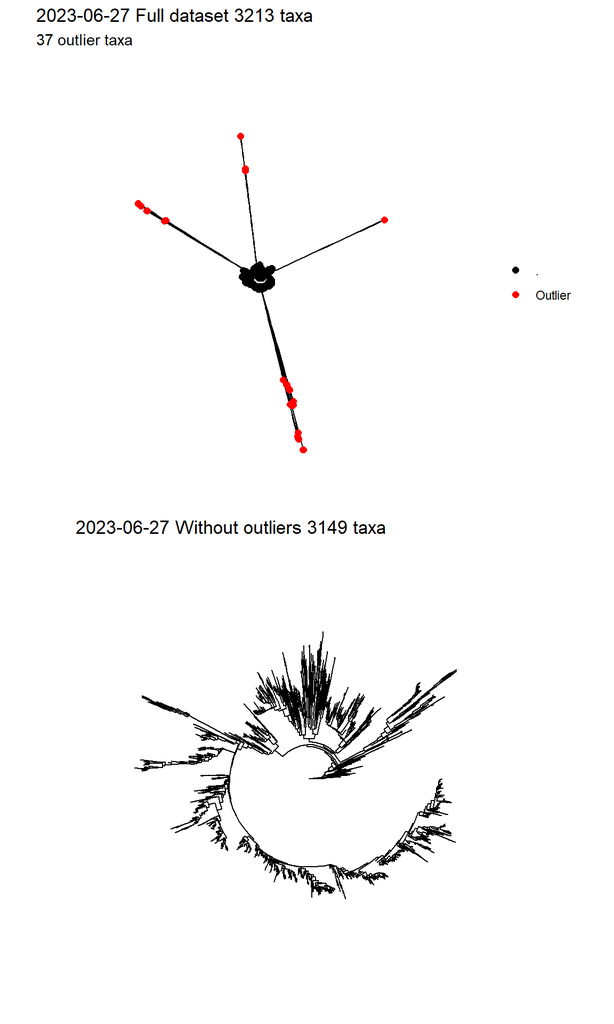

```r
removed_tree=
ggtree(phyloseq_all_sequences) + layout_circular() +
  ggtree:: geom_tippoint(aes(color = ifelse(label %in% outliers_remove$Query, "Outlier", ".")), size = 2) +
  ggplot2::scale_color_manual(values = c("." = "black", "Outlier" = "red")) +
  ggplot2::theme(legend.position = "right",
                 legend.title = element_blank()) +
  ggplot2::ggtitle(label = paste0(Sys.Date(), " Full dataset ", ntaxa(phyloseq_all_sequences), " taxa"),
                   subtitle = paste0(length(outliers_remove$Query %>% unique()), " outlier taxa"))
quality_tree =
ggtree(quality_ps) + layout_circular() +
  ggplot2::theme(legend.position = "right",
                 legend.title = element_blank()) +
  ggplot2::ggtitle(label = paste0(Sys.Date(), " Without outliers ", ntaxa(quality_ps), " taxa"))
ggpubr::ggarrange(removed_tree,quality_tree,nrow = 2)
```

```r
#ggsave(filename = paste0(filepath_results, "removed_outliers_and_new_tree.png"), width = 6, height = 10)
```

In this example it can be advisable to repeat the process as some taxa still are deviating from the phylogenetic tree.